# Scientific graphics with `ggplot2` in R

Jan K Boyer

10/1/2020

# R Graphics Packages

There are several ways to make graphs in R. R comes with graphics capability (referred to as base graphics), and packages such as `lattice` and `ggplot2` can also be used to make graphics.

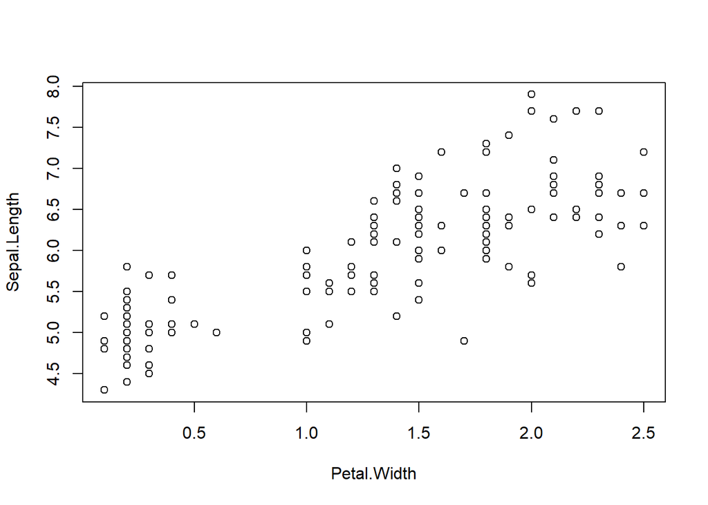

```r
plot(Sepal.Length~Petal.Width, data = iris)
```

## `lattice`

```r
require(lattice)
```

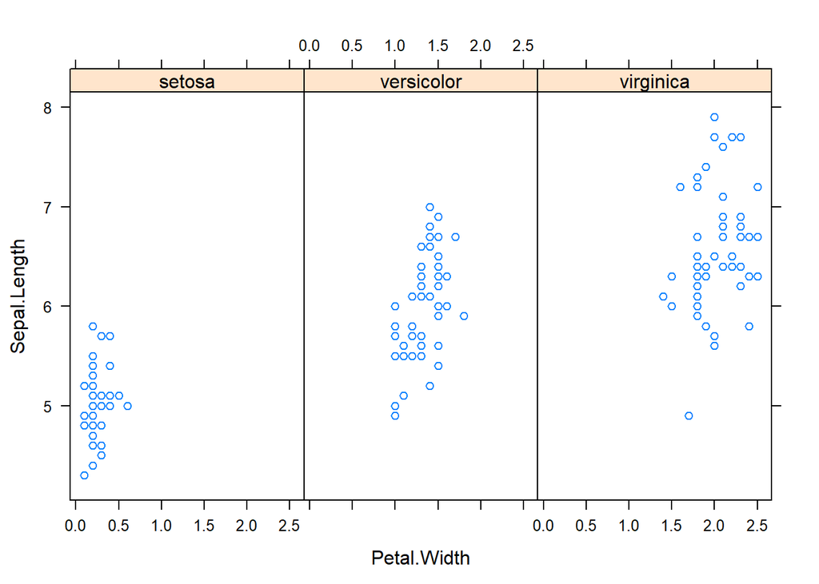

```r
xyplot(Sepal.Length~Petal.Width|Species, data = iris)
```

## `ggplot2`

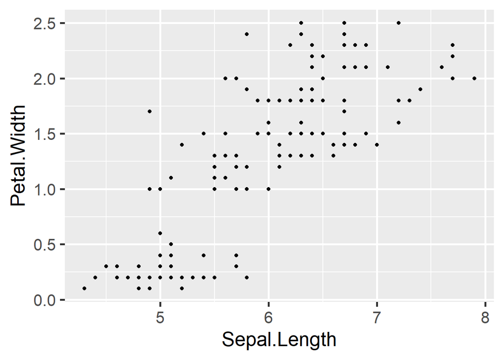

```r
require(ggplot2)
ggplot(iris, aes(x = Sepal.Length, y = Petal.Width)) +
  geom_point()
```

This course focuses on `ggplot2`, which is the package I use most often. However, you can also make excellent publication quality graphics with base graphics or `lattice`.

# Formatting data

Before making a `ggplot2’, make sure your data is in the right format:

1. All data in one dataframe
2. Data in long format
   - Each observation is a row
   - Each variable is a column
3. Column classes correct
4. Factors ordered correctly

## 1. All data in one dataframe

All of your data needs to be in one dataframe before making a ggplot. If you have different dataframes for each site, species, or replicate, or have site information in one dataframe and species data in another, you need to combine your dataframes into one before plotting.

### Add observations (rows)

If you have multiple dataframes with identical column names, you can simple paste bind the rows together:

```r
#base
#columns must match
df.all <- rbind(df1, df2)

#dplyr (tidyverse)
#can handle missing columns
require(dplyr)
df.all <- bind_rows(df1, df2)
```

### Add variables (columns)

```r
#base
df.new <- merge(df1, df2, by = "siteID") #inner
df.new <- merge(df1, df2, by = "siteID", all.x = TRUE) #left outer
df.new <- merge(df1, df2, by = "siteID", all.y = TRUE) #right outer
df.new <- merge(df1, df2, by = "siteID", all = TRUE) #outer

#dplyr (tidyverse)
#will automatically join on common column names
#use by = "siteID" to specify join variable
df.new <- df1 %>% inner_join(df2) #inner
df.new <- df1 %>% left_join(df2) #left outer
df.new <- df1 %>% right_join(df2) #right outer
df.new <- df1 %>% full_join(df2) #outer
```

### Convert wide data to long data

We often record data in wide format

| date | site | FMS | BHS | HBC |
| --- | --- | --- | --- | --- |
| 2019-06-23 | a | 23 | 14 | 1 |
| 2019-06-23 | b | 17 | 14 | 1 |
| 2019-06-23 | c | 29 | 10 | 0 |
| 2019-06-25 | a | 17 | 7 | 4 |
| 2019-06-25 | b | 23 | 13 | 2 |
| 2019-06-25 | c | 23 | 8 | 0 |

| date | site | species | catch |
| --- | --- | --- | --- |
| 2019-06-23 | a | FMS | 23 |
| 2019-06-23 | b | FMS | 17 |
| 2019-06-23 | c | FMS | 29 |
| 2019-06-25 | a | FMS | 17 |
| 2019-06-25 | b | FMS | 23 |
| 2019-06-25 | c | FMS | 23 |
| 2019-06-23 | a | BHS | 14 |
| 2019-06-23 | b | BHS | 14 |
| 2019-06-23 | c | BHS | 10 |
| 2019-06-25 | a | BHS | 7 |
| 2019-06-25 | b | BHS | 13 |
| 2019-06-25 | c | BHS | 8 |
| 2019-06-23 | a | HBC | 1 |
| 2019-06-23 | b | HBC | 1 |
| 2019-06-23 | c | HBC | 0 |
| 2019-06-25 | a | HBC | 4 |
| 2019-06-25 | b | HBC | 2 |
| 2019-06-25 | c | HBC | 0 |

##Convert wide to long

```r
#tidyverse
require(tidyr)

gather(data, key = "key", value = "value")
```

Other options:  
`datatable::melt()`  
`pivot_longer()` in development version of `tidyverse`

### Check column classes

```r
str(iris) #base r
glimpse(iris) #tidyverse
```

### Define column classes

```r
df$weight <- as.numeric(df$weight) #base

df <- df %>% mutate(weight = as.numeric(weight)) #dplyr (tidyverse)

as.numeric()
as.integer()
as.character()
as.factor()
as.Date() #format should be 2019-04-30
as.POSIXct() #format: 2019-04-30 14:22:00
```

# Order Factors

```r
#base
iris$Species <- factor(iris$Species,
                       levels = c("virginica", "versicolor", "setosa")) #<<

#dplyr (tidyverse)
iris <- iris %>%
  mutate(Species = factor(Species,
                          levels = c("virginica", "versicolor", "setosa"))) #<<

levels(iris$Species) #check they are correct now
```

```
## [1] "virginica"  "versicolor" "setosa"
```

# Making ggplots

ggplots are made out of the following elements:

### A shortcut to prettier plots:

The default theme for `ggplot2`, `theme_gray()` isn’t great.

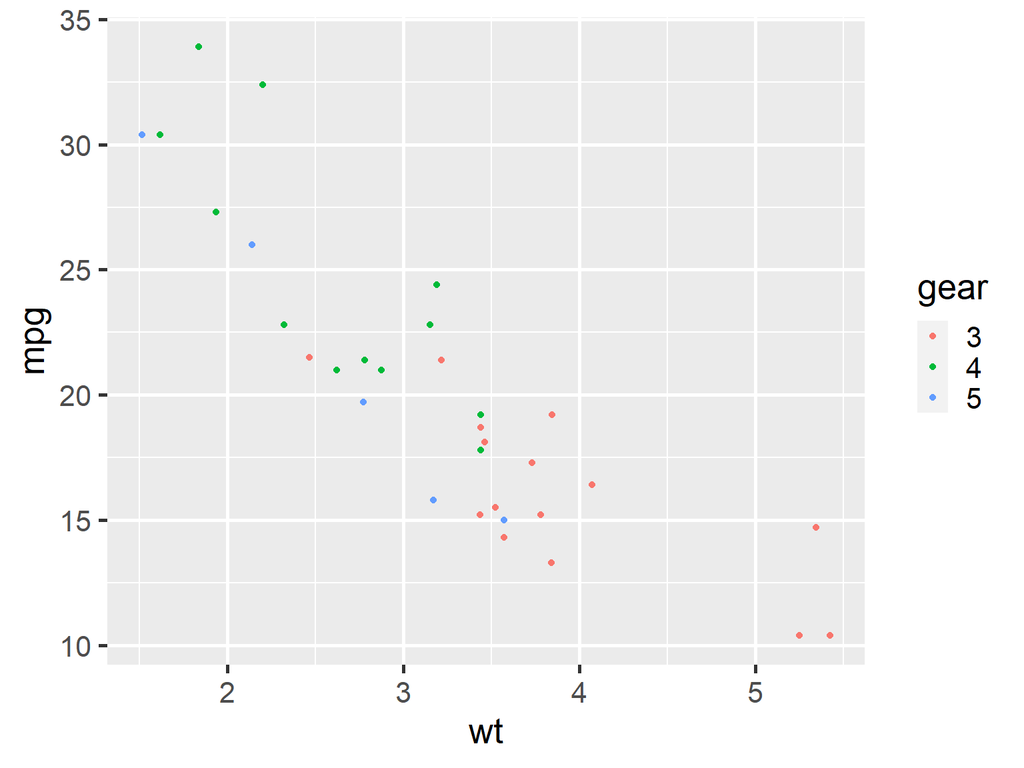

ggplot2 comes with several built in themes that are much cleaner than `theme_gray()`

[output not shown]

[output not shown]

[output not shown]

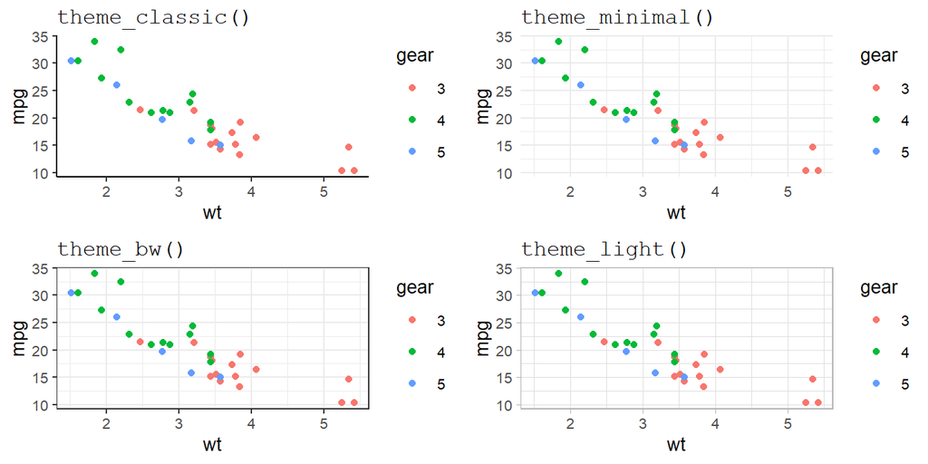

[See all built in themes](https://ggplot2.tidyverse.org/reference/index.html#section-themes)

The `theme_set()` function sets a default theme. Add `theme_set()’ with your preferred theme and font size to the top of your R script, and then all of the graphs you create in that script will use that theme.

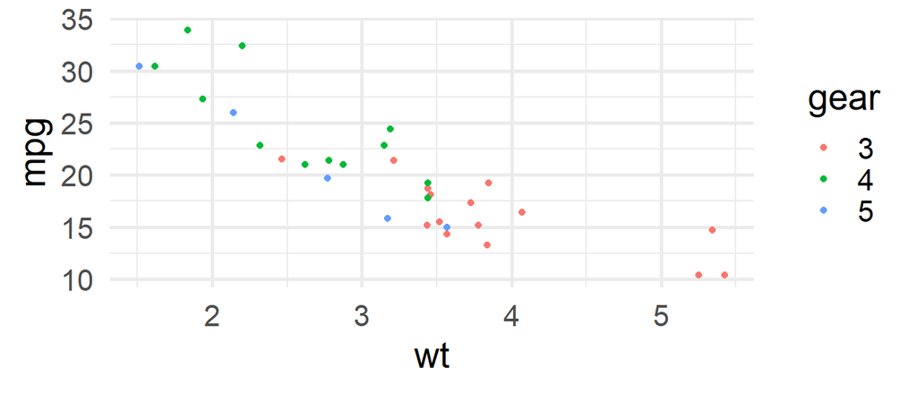

```r
theme_set(theme_minimal(base_size = 20)) #<<

ggplot(mtcars, aes(x = wt, y = mpg, color = gear)) +
  geom_point()
```